# Final Project

Austen Wyche

2023-12-08

## Introduction

The main research question is: What is the relationship between gun ownership rates and the number of mass shootings (per year) in the United States? My main hypothesis is that in years with higher gun ownership, there will be a larger number of mass shootings taking place. This is important to discover whether there is a correlation between allowing more people to own guns and more instances of violence.

In the United States, there is major debate over whether the gun ownership rate makes Americans safer or more vulnerable to danger. By analyzing the relationship between gun ownership and mass shootings, I hope to discover whether there is a relationship between the two.

## Data Section

The main outcome of interest is the number of mass shootings in the United States per year. The outcome variable of interest is measured by Mother Jones, a nonprofit organization which compiled records of mass shootings in the United States since the year 2000.

The main outcome variable of interest is the number of mass shooring instances, which is seen in the graph below.

[figure not shown]

## Results Section

As we can see below, Gallup has compiled the self-reported gun ownership rate in the United States between 2000-2018. It appears the gun ownership rate in the United States has remained relatively stable between 40% and 50% in the period of 2000-2018.

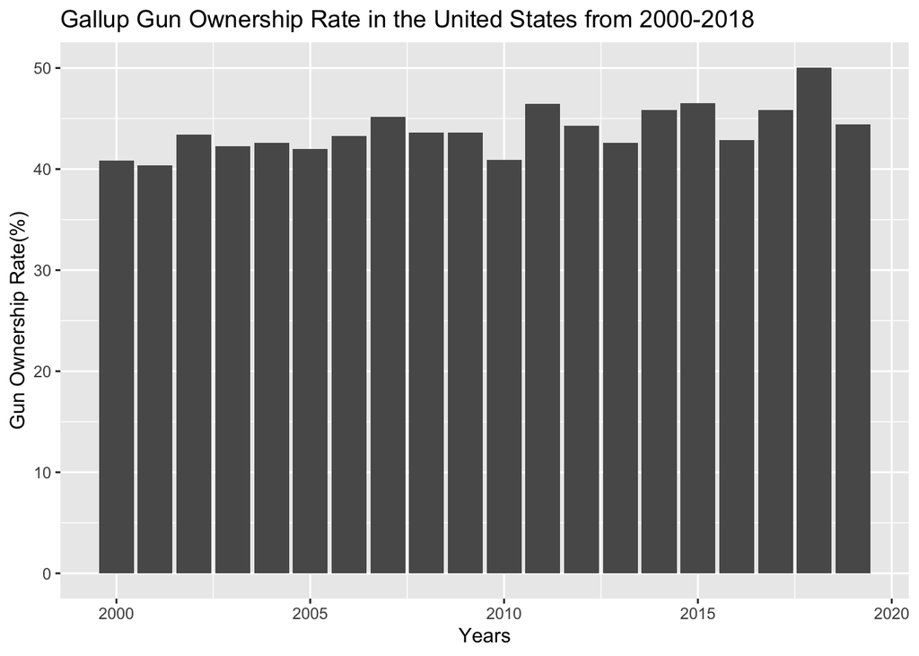

Main Relationship of Interest (Gun Ownership Rate and Number of Mass Shooting Instances). The following graph displays a linegraph of the gun ownership rate and the number of mass shooting instances. The top line represents the gun ownership rate, which remained between 40% and 50% over this period, but increased overall. The bottom line represents the number of mass shooting instances documented by Mother Jones, which has increased over this period of time to nearly 10 documented instances.

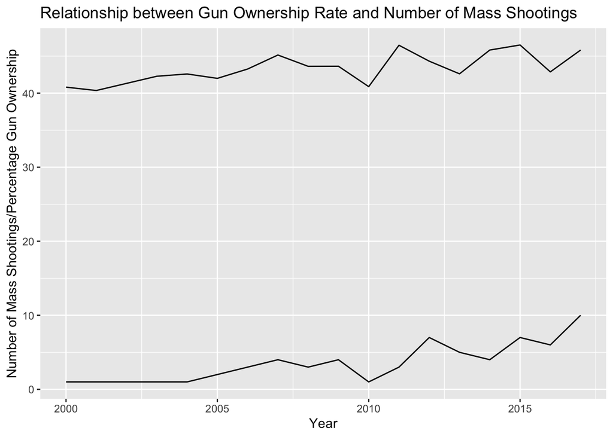

Regression of Gun Ownership Rate and Instances of Mass Shootings

```
## # A tibble: 2 × 4
##   term            est     se    pval
##   <chr>         <dbl>  <dbl>   <dbl>
## 1 (Intercept) -35.0   11.1   0.00672
## 2 OwnGuns       0.890  0.256 0.00337
```

| Term | Estimate | Standard Error | P-Value |
| --- | --- | --- | --- |
| (Intercept) | -34.9600798 | 11.1277169 | 0.0067193 |
| OwnGuns | 0.8895087 | 0.2557467 | 0.0033718 |

Furthermore, the correlation displays that for every one unit (one percent) increase in the gun ownership rate, there appears to be a .8895 increase in the number of mass shooting instances Due to this relationship, it is likely we can conclude the gun ownership rate in the United States has a positive relationship with the number of mass shooting instances.

Due to the p value of OwnGuns (.003) being less than .05, we can reject the null hypothesis that there is no relationship between the gun ownership rate and the number of mass shooting instances in the United States. Therefore, there appears to be a statistically significant relationship between the two.

While this correlation implies there is a statistically significant relationship between the gun ownership rate in the United States and the number of mass shootings, we should continue to acknowledge the number of mass shootings is likely higher than reported by Mother Jones.

## Conclusion

Overall, it appears there is statistically significant for the hypothesis that increasing the gun ownership rate in the United States has a positive relationship with the number of mass shootings rising. A potential limitation to this study is the fact that the number of mass shootings could be underreported.

In addition, a major confounding variable not accounted for in this study are gun control laws. As the United States has state-by-state policy on guns, the strict/lenient nature of a states’ gun laws affects both the gun ownership rate and the number of mass shooting instances. This factor has the ability to affect both the response and explanatory variable.

If there was more time and financial resources to create this study, I would personally document the instances of mass shootings in order to ensure the number is accurate. In addition, as this study only runs up to 2018, it would be interesting to see the trend in the years up to 2023, when mass shootings have significantly risen in the United States.